# Advanced Data Wrangling: Extracting Ecological Signals From Noisy Systems

MB5370 R4MarineScience

Author

Kylar Duffy

## Overview

This workshop focused on advanced data wrangling techniques for cleaning, restructuring and integrating ecological datasets in R. The initial exercises used the Palmer Penguins dataset to explore data standardisation, relational joins and reshaping data between long and wide formats. These skills were then applied to a Ross River Estuary fish survey, where multiple datasets containing fish catches, environmental measurements, site metadata and taxonomic information were combined to investigate patterns in fish abundance along a salinity gradient.

# Practical Exercises: Penguins, Pivots and Joining Data

## Exercise 1: Cleaning the messy metadata

Before Cleaning:

```r
# Load packages
library(tidyverse)
library(palmerpenguins)

island_metadata <- tibble(
  island_name = c(" biscoe", "Dream ", "Torgersen"),
  station_install = c("15/01/2003", "22-03-2004", "05/11/2001"),
  latitude = c(-64.81, -64.73, -64.76)
) # generate the metadata

print(island_metadata) # view metadata
```

```
# A tibble: 3 × 3
  island_name station_install latitude
  <chr>       <chr>              <dbl>
1 " biscoe"   15/01/2003         -64.8
2 "Dream "    22-03-2004         -64.7
3 "Torgersen" 05/11/2001         -64.8
```

After Cleaning:

```r
clean_metadata <- island_metadata |> # create new object
  mutate(
    island_name = str_trim(island_name), # remove hidden spaces
    island_name = str_to_title(island_name), # fix capitalisation
    station_install = dmy(station_install) # convert dates
  )

# Display cleaned metadata as a formatted table
clean_metadata |>
  rename_with(~ str_to_title(str_replace_all(.x, "_", " "))) |>
  knitr::kable(
    caption = "Cleaned island metadata following standardisation of island names and installation dates"
  )
```

Cleaned island metadata following standardisation of island names and installation dates

| Island Name | Station Install | Latitude |
| --- | --- | --- |
| Biscoe | 2003-01-15 | -64.81 |
| Dream | 2004-03-22 | -64.73 |
| Torgersen | 2001-11-05 | -64.76 |

## Exercise 2: The Relational Join

```r
# Combine clean metadata with biological data
penguins_spatial <- penguins |>
  left_join(
    clean_metadata, # keep all rows from penguins
    by = join_by(island == island_name) # match columns with different names
  )

# Display the first six rows as a formatted table
penguins_spatial |>
  head() |>
  rename_with(~ str_to_title(str_replace_all(.x, "_", " "))) |>
  knitr::kable(
    caption = "Preview of the penguin dataset combined with cleaned island metadata",
    digits = 2
  )
```

Preview of the penguin dataset combined with cleaned island metadata

| Species | Island | Bill Length Mm | Bill Depth Mm | Flipper Length Mm | Body Mass G | Sex | Year | Station Install | Latitude |
| --- | --- | --- | --- | --- | --- | --- | --- | --- | --- |
| Adelie | Torgersen | 39.1 | 18.7 | 181 | 3750 | male | 2007 | 2001-11-05 | -64.76 |
| Adelie | Torgersen | 39.5 | 17.4 | 186 | 3800 | female | 2007 | 2001-11-05 | -64.76 |
| Adelie | Torgersen | 40.3 | 18.0 | 195 | 3250 | female | 2007 | 2001-11-05 | -64.76 |
| Adelie | Torgersen | NA | NA | NA | NA | NA | 2007 | 2001-11-05 | -64.76 |
| Adelie | Torgersen | 36.7 | 19.3 | 193 | 3450 | female | 2007 | 2001-11-05 | -64.76 |
| Adelie | Torgersen | 39.3 | 20.6 | 190 | 3650 | male | 2007 | 2001-11-05 | -64.76 |

## Exercise 3: The Wide Summary Matrix

```r
# Step 1. Remove penguins with missing body mass
penguins_spatial |>
  drop_na(body_mass_g) |>
  head() |>
  rename_with(~ str_to_title(str_replace_all(.x, "_", " "))) |>
  knitr::kable(
    caption = "Preview of penguin records after removing missing body mass values",
    digits = 2
  )
```

Preview of penguin records after removing missing body mass values

| Species | Island | Bill Length Mm | Bill Depth Mm | Flipper Length Mm | Body Mass G | Sex | Year | Station Install | Latitude |
| --- | --- | --- | --- | --- | --- | --- | --- | --- | --- |
| Adelie | Torgersen | 39.1 | 18.7 | 181 | 3750 | male | 2007 | 2001-11-05 | -64.76 |
| Adelie | Torgersen | 39.5 | 17.4 | 186 | 3800 | female | 2007 | 2001-11-05 | -64.76 |
| Adelie | Torgersen | 40.3 | 18.0 | 195 | 3250 | female | 2007 | 2001-11-05 | -64.76 |
| Adelie | Torgersen | 36.7 | 19.3 | 193 | 3450 | female | 2007 | 2001-11-05 | -64.76 |
| Adelie | Torgersen | 39.3 | 20.6 | 190 | 3650 | male | 2007 | 2001-11-05 | -64.76 |
| Adelie | Torgersen | 38.9 | 17.8 | 181 | 3625 | female | 2007 | 2001-11-05 | -64.76 |

```r
# Step 2. Group by species and island
max_mass_table <- penguins_spatial |>
  drop_na(body_mass_g) |> # keep only rows that have an actual value
  group_by(species, island) |> # consider each species x island combo separately
  summarise(
    max_body_mass = max(body_mass_g),
    .groups = "drop"
  ) |>
  pivot_wider(
    names_from = island, # take values from island and turn into column names
    values_from = max_body_mass # put max body mass into columns
  )

# Display the maximum body mass table
max_mass_table |>
  rename_with(~ str_to_title(str_replace_all(.x, "_", " "))) |>
  knitr::kable(
    caption = "Maximum penguin body mass (g) by species and island",
    digits = 0,
    na = "—"
  )
```

Maximum penguin body mass (g) by species and island

| Species | Biscoe | Dream | Torgersen |
| --- | --- | --- | --- |
| Adelie | 4775 | 4650 | 4700 |
| Chinstrap | NA | 4800 | NA |
| Gentoo | 6300 | NA | NA |

# Keystone Exercise: Estuary Fish Survey - Data Rescue Mission

## Phase 1: Ingestion and Decontamination

```r
# Load packages
library(tidyverse)
library(readxl)

# Import CSV datasets
metadata <- read_csv(
  here::here("data/workshop2/estuary_metadata.csv"))

sonde_data <- read_csv(
  here::here("data/workshop2/estuary_sonde_data.csv"))

species_dictionary <- read_csv(
  here::here("data/workshop2/species_dictionary.csv"))

catch_sheets <- excel_sheets(
  here::here("data/workshop2/estuary_catch_log.xlsx"))

catch_sheets # view the sheet names

# Read all catch log tabs and combine them into one data frame
catch_data <- map_dfr( # combine all sheets into one data frame by rows
  catch_sheets,
  ~ read_excel(
    here::here("data/workshop2/estuary_catch_log.xlsx"),
    sheet = .x)) # .x is a placeholder for the sheet name

# String standardisation, site and species name
catch_data <- catch_data |>
  mutate(
    site = str_to_lower(site),
    site = str_replace_all(site, " ", "_"),
    species = str_to_lower(species),
    species = str_replace_all(species, " ", "_"))
unique(catch_data$site) # check that above worked
unique(catch_data$species) # check that above worked

# Clean metadata site names
metadata <- metadata |>
  mutate(
    site_name = str_to_lower(site_name),
    site_name = str_replace_all(site_name, " ", "_"))
unique(metadata$site_name) # check

# Check species dictionary
species_dictionary # names match already so no need to clean

# Temporal parsing
glimpse(sonde_data) # tells us what the data types are for each column, timestamp is character data
head(sonde_data$timestamp) # see format of timestamps

# Parse the timestamp
sonde_data <- sonde_data |>
  mutate(
    timestamp = dmy_hm(timestamp))
glimpse(sonde_data) # check that timestamp is now a date-time object

# Remove hardware errors
sum(sonde_data$turbidity == -999, na.rm = TRUE) # check how many -999 values are in the turbidity column
sonde_data <- sonde_data |>
  mutate(
    turbidity = na_if(turbidity, -999)) # replace -999 with NA
sum(sonde_data$turbidity == -999, na.rm = TRUE) # check if worked
```

## Phase 2: Relational Architecture

```r
# Summarise the water sensor data into a daily summary table
sonde_data <- sonde_data |>
  mutate(
    date = floor_date(timestamp, unit = "day")) # create a day variable

# Create a daily summary table
sonde_daily <- sonde_data |>
  group_by(site, date) |> # treats each site on each day as a group
  summarise(
    mean_temperature = mean(temperature, na.rm = TRUE), # daily mean temp
    mean_salinity = mean(salinity, na.rm = TRUE), # daily mean salinity
    .groups = "drop") # return finished table without keeping it grouped

# Taxonomic translation
catch_translated <- catch_data |>
  left_join(
    species_dictionary,
    by = c("species" = "common_name")) # add scientific names to the catch data
sum(is.na(catch_translated$scientific_name)) # check
catch_translated <- catch_translated |>
  select(-species) # remove the common name column

# The grand join
master_data <- catch_translated |>
  left_join(
    metadata,
    by = c("site" = "site_name")) # join catch data with spatial metadata
master_data <- master_data |>
  left_join(
    sonde_daily,
    by = c("site", "date")) # join daily water quality
```

## Phase 3: Zero-Catch Framework

```r
# Check structure of sampling days
master_data |>
  distinct(site, date) |>
  count(site) # tells us how many days of sampling were done at each site

# Complete all species across every site and sampling day
master_data <- master_data |>
  complete(
    nesting(site, date),
    scientific_name
  ) # make sure all species appear for every site x day, if a species wasn't recorded complete() will create a missing row
glimpse(master_data) # check new rows were added

master_data |>
  summarise(
    missing_count = sum(is.na(count)),
    missing_zone = sum(is.na(zone)),
    missing_salinity = sum(is.na(mean_salinity))) # confirm NA counts

# Restore the spatial metadata for completed zero-catch rows
master_data <- master_data |>
  select(-lat, -lon, -zone) |>
  left_join(
    metadata,
    by = c("site" = "site_name"))
sum(is.na(master_data$zone)) # check

# Restore water quality data for completed zero-catch rows
master_data <- master_data |>
  select(-mean_temperature, -mean_salinity) |>
  left_join(
    sonde_daily,
    by = c("site", "date"))
sum(is.na(master_data$mean_salinity)) # check

# Replace missing catch values with zero
master_data <- master_data |>
  mutate(
    count = coalesce(count, 0)) # keep the existing count where there is one; if count is NA , use 0 instead
sum(is.na(master_data$count)) # check
```

```r
# Display the first six rows of the completed master dataset
master_data |>
  head(6) |>
  mutate(
    site = str_to_title(str_replace_all(site, "_", " ")),
    scientific_name = str_to_sentence(str_replace_all(scientific_name, "_", " "))
  ) |>
  rename_with(~ str_to_title(str_replace_all(.x, "_", " "))) |>
  knitr::kable(
    caption = "Preview of the cleaned estuary fish survey dataset",
    digits = 2
  )
```

Preview of the cleaned estuary fish survey dataset

| Site | Date | Scientific Name | Count | Lat | Lon | Zone | Mean Temperature | Mean Salinity |
| --- | --- | --- | --- | --- | --- | --- | --- | --- |
| Lower Ross | 2026-05-01 | Acanthopagrus spp. | 4 | -19.26 | 146.81 | Downstream | 23.79 | 28.35 |
| Lower Ross | 2026-05-01 | Lates calcarifer | 6 | -19.26 | 146.81 | Downstream | 23.79 | 28.35 |
| Lower Ross | 2026-05-01 | Lutjanus argentimaculatus | 3 | -19.26 | 146.81 | Downstream | 23.79 | 28.35 |
| Lower Ross | 2026-05-01 | Platycephalus spp. | 2 | -19.26 | 146.81 | Downstream | 23.79 | 28.35 |
| Lower Ross | 2026-05-02 | Acanthopagrus spp. | 3 | -19.26 | 146.81 | Downstream | 23.98 | 27.74 |
| Lower Ross | 2026-05-02 | Lates calcarifer | 1 | -19.26 | 146.81 | Downstream | 23.98 | 27.74 |

## Phase 4: Statistical Extraction

```r
# Calculate summary statistics for fish catch
summary_data <- master_data |>
  group_by(scientific_name, zone) |>
  summarise(
    mean_count = mean(count, na.rm = TRUE),
    sd_count = sd(count, na.rm = TRUE),
    se_count = sd_count / sqrt(sum(!is.na(count))),
    salinity_mean = mean(mean_salinity, na.rm = TRUE),
    salinity_sd = sd(mean_salinity, na.rm = TRUE),
    salinity_se = salinity_sd / sqrt(sum(!is.na(mean_salinity))),
    .groups = "drop")

# Round numerical values for presentation
summary_table <- summary_data |>
  mutate(
    zone = factor(
      zone,
      levels = c("Upstream", "Middle", "Downstream", "Marine")
    )
  ) |>
  arrange(scientific_name, zone) |>
  mutate(
    across(
      where(is.numeric),
      ~ round(.x, 2)
    )
  )

# Check site metadata before visualisation
metadata

# Set estuary zones in spatial order from upstream to marine
master_data <- master_data |>
  mutate(
    zone = factor(
      zone,
      levels = c("Upstream", "Middle", "Downstream", "Marine")
    )
  )

# Check the order of estuary zones
levels(master_data$zone)
```

```r
# Display the statistical summary as a formatted table
knitr::kable(
  summary_table,
  caption = "Mean, standard deviation and standard error of fish catch and salinity by species and estuary zone",
  col.names = c(
    "Scientific name",
    "Estuary zone",
    "Mean catch",
    "SD catch",
    "SE catch",
    "Mean salinity",
    "SD salinity",
    "SE salinity"
  ),
  digits = 2,
  na = "—"
)
```

Mean, standard deviation and standard error of fish catch and salinity by species and estuary zone

| Scientific name | Estuary zone | Mean catch | SD catch | SE catch | Mean salinity | SD salinity | SE salinity |
| --- | --- | --- | --- | --- | --- | --- | --- |
| Acanthopagrus spp. | Upstream | 2.57 | 1.65 | 0.30 | 4.95 | 0.19 | 0.03 |
| Acanthopagrus spp. | Middle | 2.23 | 1.57 | 0.29 | 14.91 | 0.40 | 0.07 |
| Acanthopagrus spp. | Downstream | 2.00 | 1.51 | 0.28 | 27.97 | 0.35 | 0.06 |
| Acanthopagrus spp. | Marine | 2.33 | 1.88 | 0.34 | 34.02 | 0.10 | 0.02 |
| Lates calcarifer | Upstream | 4.80 | 1.69 | 0.31 | 4.95 | 0.19 | 0.03 |
| Lates calcarifer | Middle | 2.20 | 1.32 | 0.24 | 14.91 | 0.40 | 0.07 |
| Lates calcarifer | Downstream | 1.60 | 1.40 | 0.26 | 27.97 | 0.35 | 0.06 |
| Lates calcarifer | Marine | 1.57 | 1.36 | 0.25 | 34.02 | 0.10 | 0.02 |
| Lutjanus argentimaculatus | Upstream | 1.90 | 1.16 | 0.21 | 4.95 | 0.19 | 0.03 |
| Lutjanus argentimaculatus | Middle | 1.97 | 1.13 | 0.21 | 14.91 | 0.40 | 0.07 |
| Lutjanus argentimaculatus | Downstream | 2.00 | 1.64 | 0.30 | 27.97 | 0.35 | 0.06 |
| Lutjanus argentimaculatus | Marine | 1.50 | 1.14 | 0.21 | 34.02 | 0.10 | 0.02 |
| Platycephalus spp. | Upstream | 2.30 | 1.82 | 0.33 | 4.95 | 0.19 | 0.03 |
| Platycephalus spp. | Middle | 1.97 | 1.45 | 0.26 | 14.91 | 0.40 | 0.07 |
| Platycephalus spp. | Downstream | 2.10 | 0.96 | 0.18 | 27.97 | 0.35 | 0.06 |
| Platycephalus spp. | Marine | 5.67 | 1.30 | 0.24 | 34.02 | 0.10 | 0.02 |

## Phase 5: Visual Communication

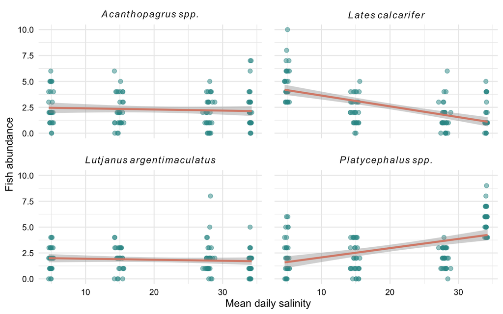

Relationship between mean daily salinity and fish abundance across the Ross River Estuary for four fish taxa. Teal points represent individual catch observations, orange lines show fitted linear trends, and grey shading indicates 95% confidence intervals.

```r
# Create italic facet labels
species_labels <- c(
  "Acanthopagrus spp." = "italic(Acanthopagrus~spp.)",
  "Lates calcarifer" = "italic(Lates~calcarifer)",
  "Lutjanus argentimaculatus" = "italic(Lutjanus~argentimaculatus)",
  "Platycephalus spp." = "italic(Platycephalus~spp.)") # create a set of labels for scientific names

# Apply italic labels
fish_salinity_plot <- ggplot(
  master_data,
  aes(x = mean_salinity, y = count)
) +
  geom_point(
    size = 2,
    alpha = 0.5,
    colour = "#319795"
  ) +
  geom_smooth(
    method = "lm",
    se = TRUE,
    colour = "#D98B78"
  ) +
  facet_wrap(
    ~ scientific_name,
    labeller = as_labeller(species_labels, label_parsed)
  ) +
  labs(
    x = "Mean daily salinity",
    y = "Fish abundance"
  ) +
  theme_minimal(base_size = 12) +
  theme(
    axis.text = element_text(colour = "black"),
    axis.title = element_text(size = 12),
    strip.text = element_text(size = 11),
    panel.spacing = unit(1, "lines")
  )

fish_salinity_plot
```

#### Ecological Interpretation

The Ross River Estuary dataset revealed differences in fish abundance across the salinity gradient, with species exhibiting distinct distribution patterns. Mean daily salinity increased from approximately 4.95 in the upstream zone to 34.02 in the marine zone. Lates calcarifer showed the strongest negative relationship with salinity, with mean catches decreasing from 4.80 upstream to 1.57 in the marine zone. Conversely, Platycephalus spp. exhibited a positive relationship, with mean catches increasing from 2.30 upstream to 5.67 in the marine zone. Acanthopagrus spp. and Lutjanus argentimaculatus displayed comparatively weak relationships with salinity, suggesting relatively consistent abundance across the estuarine gradient.

These patterns suggest that different fish taxa may vary in their habitat use along the estuary, potentially reflecting differences in environmental preferences or ecological requirements. The contrasting trends observed for L. calcarifer and Platycephalus spp. highlight how estuarine environmental gradients may influence fish assemblage composition. However, these relationships are descriptive and additional statistical analyses would be required to determine their significance. Furthermore, other environmental factors, including habitat structure, temperature and prey availability may contribute to the observed differences in abundance.

### Workshop Reflection

This workshop expanded my understanding of data wrangling in R by introducing more complex techniques for cleaning, restructuring and combining ecological datasets. Building on the skills developed in Workshop 1, I gained experience using new functions to prepare data for analysis. The Ross River Estuary exercise was particularly valuable in demonstrating how raw ecological datasets often require substantial processing before meaningful patterns can be investigated.

One of the most important concepts explored was the distinction between missing values and genuine zero observations. Creating a zero-catch framework helped to understand how overlooking species absences could influence summary statistics and lead to misleading ecological interpretations. I also developed a greater understanding for the importance of standardising variable names, checking data types and ensuring datasets are compatible before joining them.

One particularly useful skill was using the here::here() function to manage file paths within an R project. I found this valuable because it provides a more reliable way to locate and import datasets without relying on computer-specific file paths.

Overall, this workshop strengthened my understanding of reproducible data workflows and increased my confidence in working with more complex ecological datasets.